# Homework 8

Tauqeer Kasam Rumaney

December 11, 2022

Download this R Markdown file, save it on your computer, and perform all the below tasks by inserting your answer in text or by inserting R chunks below. After you are done, upload this file with your solutions on Moodle.

```r
dat_link <- url("https://www.dropbox.com/s/pd0z829pv2otzqt/KiGGS03_06.RData?dl=1")
load(dat_link)
dat <- KiGGS03_06
```

## Exercise 1: Correlation

1. In the KiGGS dataset, compute the Pearson and Spearman correlation coefficient for the two variables ‘sys1’ and ‘sys2’ and hypothesis tests whether the two variables are associated or not. Interpret the results, and decide which of the two coefficients you would report in your analysis and why.

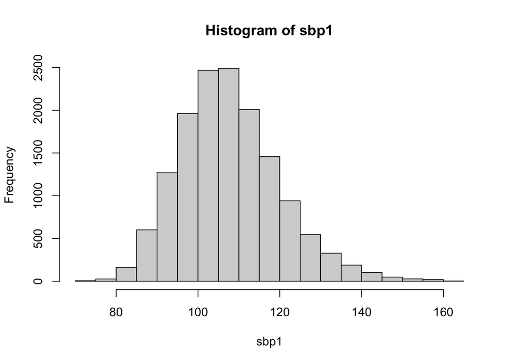

```r
sbp1 <- as.numeric(as.character(dat$sys1))
sbp2 <- as.numeric(as.character(dat$sys2))
hist(sbp1)
```

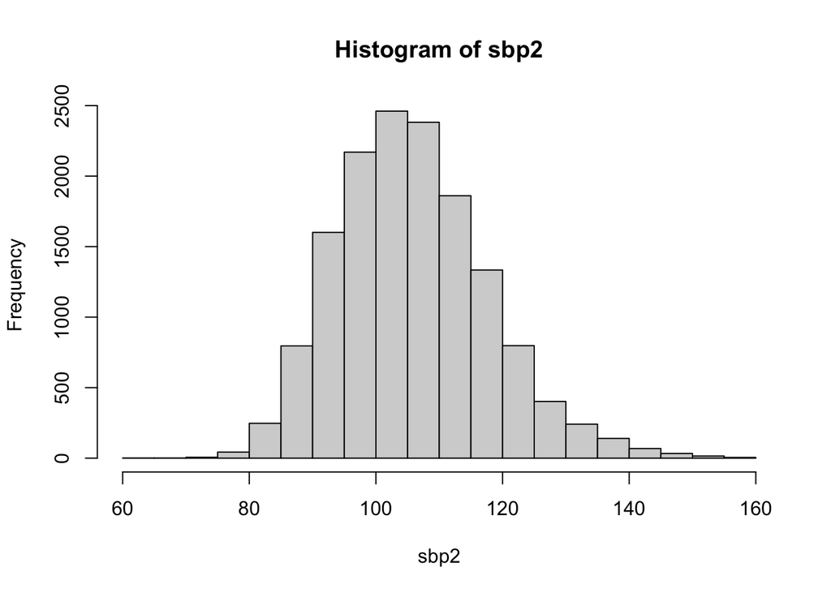

```r
hist(sbp2)
```

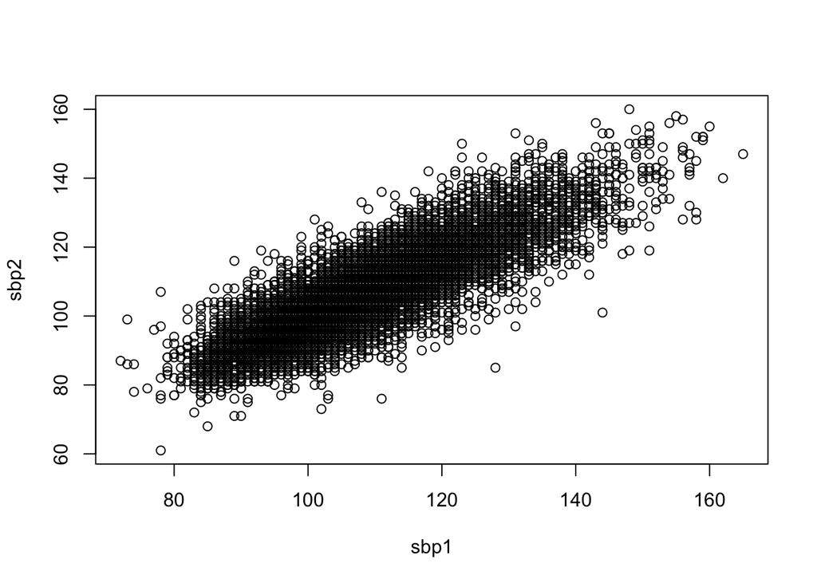

```r
plot(sbp1,sbp2)
```

```r
res <- cor.test(sbp1, sbp2, use = "complete.obs", method = "pearson")
res #Pearson
```

```
##
##  Pearson's product-moment correlation
##
## data:  sbp1 and sbp2
## t = 193.34, df = 14563, p-value < 2.2e-16
## alternative hypothesis: true correlation is not equal to 0
## 95 percent confidence interval:
##  0.8436990 0.8528071
## sample estimates:
##       cor
## 0.8483158
```

```r
cor(sbp1, sbp2, use = "complete.obs", method = "spearman") #Spearman
```

```
## [1] 0.8405508
```

Conclusion: We can conclude that ‘sys1’ and ‘sys2’ are significantly correlated with a correlation coefficient of 0.84 and p-value of 2.2^{-16}. We will report the Pearson coefficient since both the variables are metric variables as well as they are normally distributed

2. Optional: Compute confidence intervals of the correlation coefficient estimates from part a). Note: for confidence intervals of the Spearman coefficient, you need another function.

```r
res$conf.int
```

```
## [1] 0.8436990 0.8528071
## attr(,"conf.level")
## [1] 0.95
```

```r
#SpearmanRho(sbp1,sbp2, conf.level=0.95)
#Error in SpearmanRho(sbp1, sbp2, conf.level = 0.95) : could not find function "SpearmanRho"
```

## Exercise 2: Linear regression

1. Predict sys2 by sys1 using a simple linear regression, and interpret the results.

```r
res1 <- lm(sbp2 ~ sbp1)
summary(res1)
```

```
##
## Call:
## lm(formula = sbp2 ~ sbp1)
##
## Residuals:
##     Min      1Q  Median      3Q     Max
## -37.677  -3.869  -0.158   3.842  31.458
##
## Coefficients:
##              Estimate Std. Error t value Pr(>|t|)
## (Intercept) 16.828706   0.465916   36.12   <2e-16 ***
## sbp1         0.826940   0.004277  193.34   <2e-16 ***
## ---
## Signif. codes:  0 '***' 0.001 '**' 0.01 '*' 0.05 '.' 0.1 ' ' 1
##
## Residual standard error: 6.305 on 14563 degrees of freedom
##   (3075 observations deleted due to missingness)
## Multiple R-squared:  0.7196, Adjusted R-squared:  0.7196
## F-statistic: 3.738e+04 on 1 and 14563 DF,  p-value: < 2.2e-16
```

```r
head(predict(res1))
```

```
##         1         2         3         4         5         8
## 101.17660 102.83049 106.96519 113.58071  98.69578  99.52272
```

Conclusion: Since the p-value is less than 0.05, we are confident that the coefficients i.e. β0 and β1 are not zero, meaning the coefficients does in fact add value to the model by helping to explain the variance within our dependent variable and thus null hypothesis is rejected.

2. Add age2 and sex as predictors to the linear regression model above, and interpret the results.

```r
age2 <- dat$age2
table(age2)
```

```
## age2
##   0 - 1 J.   2 - 3 J.   4 - 5 J.   6 - 7 J.   8 - 9 J. 10 - 11 J. 12 - 13 J.
##       1860       1879       1935       2032       2104       2076       2018
## 14 - 15 J. 16 - 17 J.
##       1972       1764
```

```r
sex <- dat$sex
res2 <- lm(sbp2 ~ sbp1 + age2 + sex)
summary(res2)
```

```
##
## Call:
## lm(formula = sbp2 ~ sbp1 + age2 + sex)
##
## Residuals:
##     Min      1Q  Median      3Q     Max
## -36.234  -3.822  -0.176   3.643  30.566
##
## Coefficients:
##                 Estimate Std. Error t value Pr(>|t|)
## (Intercept)    24.760399   0.562703  44.003  < 2e-16 ***
## sbp1            0.732741   0.005223 140.290  < 2e-16 ***
## age24 - 5 J.   -0.332119   0.257240  -1.291 0.196695
## age26 - 7 J.    0.686938   0.254888   2.695 0.007046 **
## age28 - 9 J.    1.761537   0.254915   6.910 5.04e-12 ***
## age210 - 11 J.  2.682674   0.258091  10.394  < 2e-16 ***
## age212 - 13 J.  3.598362   0.265083  13.574  < 2e-16 ***
## age214 - 15 J.  4.546516   0.273090  16.648  < 2e-16 ***
## age216 - 17 J.  5.357295   0.283371  18.906  < 2e-16 ***
## sexWeiblich    -0.359876   0.101762  -3.536 0.000407 ***
## ---
## Signif. codes:  0 '***' 0.001 '**' 0.01 '*' 0.05 '.' 0.1 ' ' 1
##
## Residual standard error: 6.119 on 14555 degrees of freedom
##   (3075 observations deleted due to missingness)
## Multiple R-squared:  0.7361, Adjusted R-squared:  0.7359
## F-statistic:  4511 on 9 and 14555 DF,  p-value: < 2.2e-16
```

```r
head(predict(res2))
```

```
##         1         2         3         4         5         8
## 103.09836 103.64816 106.03085 114.67776  96.96966  97.34252
```

Conclusion: We can interpret that group 4-5 J. in ‘age2’ variable ais not significant in the multiple regression model. This mean that it is possible for us to remove them from our model since removing it won’t significantly affect our results. I also don’t know why in ‘age2’ variable group 2-3 J. is skipped (would be helpful if you can answer it in feedback).

## Exercise 3: Visualization of regression (optional)

Use the functions in ggplot2 to compute a scatter plot and insert the regression line of the analysis in exercise 2a.

```r
library(tidyverse)
```

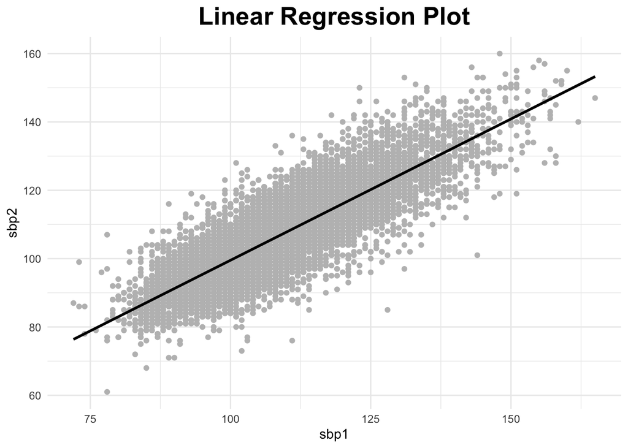

```r
ggplot(data = dat, aes(x = sbp1, y = sbp2)) +
  geom_point(color = "grey") +
  geom_smooth(method='lm',color='black') +
  theme_minimal() +
  labs(x='sbp1', y='sbp2', title='Linear Regression Plot')+
  theme(plot.title = element_text(hjust=0.5, size=20, face='bold'))
```